# Artificial Intelligence for Data Analysis | MTA Workshop

## Artificial Intelligence for Data Analysis

[figure not shown]

Andre A. Cire

andre.cire@rotman.utoronto.ca

Management Technology Association Workshop

November 2026

[figure not shown]

Open the workshop slides

www.andre-cire.com/ai-mta2026/

## We start with a problem

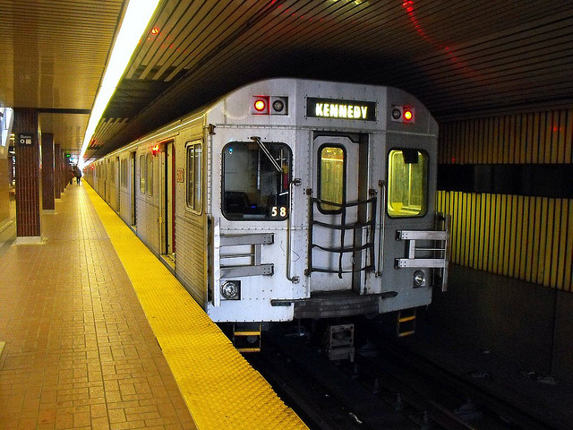

Kipling station, 2009. [Buddahbless](https://commons.wikimedia.org/wiki/File:Kipling_TTC_end_of_the_line.jpg), [CC BY 2.0](https://creativecommons.org/licenses/by/2.0/). Cropped.

Subway delays leave  
passengers needing help.

- Crowded platforms.
- Door problems.
- Weather disruptions.

[Door and weather examples: TTC delay records](https://open.toronto.ca/dataset/ttc-subway-delay-data/)

Where and when should extra support go?

## Our goal today

TTC hired you to **assign support teams** to stations.

Place teams where and when they maximize the number of passengers helped.

**Your decision**

**3** station–time pairs

**Duration**

**2 hours** per time window

Expected passengers needing help

0

Total across your selections · Illustrative estimates

Prediction

How many passengers may need help?

Optimization

Which three pairs should we choose?

**15 stations** · Example time windows

| Station | 07–09 | 12–14 | 16–18 |
| --- | --- | --- | --- |

0 / 3 pairs selected

Select a cell. See the expected passengers on the left.

## Data

When TTC records a subway delay, it logs the **time, station, reported issue, and delay duration.**

One row = one recorded delay entry

| Date | Time | Station | Reported issue | Delay (min) |
| --- | --- | --- | --- | --- |

....

[Source: City of Toronto Open Data](https://open.toronto.ca/dataset/ttc-subway-delay-data/)

708

positive-delay log entries

15 stations · Weekdays  
January–September 2025

Download CSV

January–September 2025

Turn evidence into **actions.**

AI will help us inspect the data, make predictions, and compare decisions.

## Leveraging AI tools

To use them effectively, we need to understand how they work.

**Intuition:** predict the next token based on all information so far, and pick the most likely next one.

Text so far

The next train arrives in

A token is a word or part of a word.

Patterns learned  
from training data

Possible next tokens

Illustrative probabilities

Try completing the sentence.

Frontier model families

[GPT](https://developers.openai.com/api/docs/models/all) / [Claude](https://platform.claude.com/docs/en/models/overview)

Advanced general-purpose capabilities

Open-weight examples

[Qwen](https://qwen.readthedocs.io/en/stable/getting_started/concepts.html) / [gpt-oss](https://developers.openai.com/api/docs/models/all)

Downloadable weights, subject to a licence

Each model has their own capabilities and features.

## Should we just “one-shot”?

That is, simply upload the data and ask for the final recommendation in one prompt.

|  | One shot is best when... | Step by step is best when... |
| --- | --- | --- |
| Risk | Low stakes, easy to check | Consequences call for explicit checks |
| Differentiation | A standard, common answer is enough | Your framing and assumptions add value |
| Complexity | Simple and short | Answers are long, multi-layered |
| Understanding | Only high-level or none is enough | Understand choices and intermediate results |
| Effort | Small (for instance, a fast starting point) | More interaction and judgement |

Principle: choose option based on your objective, assumptions, and checks.  
**AI can support you either situations.**

Exercise: which approach would you choose in each case?

01

### Summarize an event invitation

You can check the date, location, and details.

02

### Choose TTC stations and times

Three choices. Uncertain delays. Compare expected passenger needs.

03

### Enter an analytics competition

Other teams have access to comparable AI models.

## Data analysis process

01

### Understand the data

What does each row mean?

→

02

### Identify patterns

What changes by station or time?

→

03

### Make predictions

What might happen next?

Fundamental principal: **Visualize** what you find and **explain** what it means.

Visualization and interpretability matter at every step.

## Understand the data

01

### Read rows and columns

Explain one entry in plain language.

02

### Check units and counts

Minutes measure delay.  
Rows count recorded entries.

03

### Look for errors

Check missing values, repeated entries,  
and unexpected values.

Read a real TTC entry

| Date / time | Station | Reported issue | Delay (min) |
| --- | --- | --- | --- |

At 08:13, a rail-related problem at Bloor-Yonge was logged with a 9-minute delay.

**708 entries**across 15 stationsPassenger counts require another source.

A quick check of this extract

**0** missing core values**0** exact repeat rows

## Constructing a useful prompt

A good prompt makes the task, contextual information, and expected answer clear. You design it based on four dimensions (and more as you become more advanced):

01

### Task

What should AI do?

> Count the rows in the file.

02

### Context

What information should it use?

> Use the attached TTC delay CSV.

03

### Output format

What should the answer look like?

> Return the count in one sentence.

04

### Checks

What rules should it follow?

> Exclude the header. Count every data row.

**Always start simple, check the answer, and refine the prompt iteratively.**

Example: *Count the rows in the file using the attached TTC delay CSV. Return the count in one sentence.*[Adapted from OpenAI’s prompting guidance](https://developers.openai.com/api/docs/guides/prompt-engineering)

## Hands-on: understand the TTC data

Let's see standard first prompt in data analysis!

Try asking GPT, Claude, or your favorite AI

[Source: TTC delay records · Prepared January–September 2025 extract](https://open.toronto.ca/dataset/ttc-subway-delay-data/)

Be precise and **take your time writing a prompt**: the more information, the better context and outcomes.

## Identifying patterns

[figure not shown]

### Questions

Explore distributions and relationships across one or more columns.

Each question becomes a prompt.

### Analysis

Use a plot or a statistic to answer the question.

Mean · Standard deviation · Correlation

### Insights

Explain what you learned and what deserves a closer look.

What will you ask next?

## Example: delay minutes by station

How many **total delay minutes** were recorded at each station during the data period?

Try asking GPT, Claude, or your favorite AI

[Source: TTC delay records · Prepared January–September 2025 extract](https://open.toronto.ca/dataset/ttc-subway-delay-data/)

## Example: distributions

Does the **day of the week** matter for the **delay duration**?

Try asking GPT, Claude, or your favorite AI

Draw a histogram of delay minutes for each weekday. Use matching bins and axes, show percentages, and use different colors. Describe differences in the distributions.

Positive-delay entries only · Same bins and percentage scale

[Source: TTC delay records · Prepared January–September 2025 extract](https://open.toronto.ca/dataset/ttc-subway-delay-data/)

## Example: correlation and relationships between columns

Do **longer delays** go with **longer gaps between trains**?

**Scatter plot:** one dot per recorded event.Delay minutes ↔ Minutes between trains

Try asking GPT, Claude, or your favorite AI

Plot Min Delay against Min Gap, with delay on the horizontal axis. Calculate Pearson’s correlation and explain it. Add a zoomed view while keeping all entries.

Pearson’s **r** ranges from −1 to +1.  
Correlation does not establish causation.

[Source: TTC delay records · Prepared January–September 2025 extract](https://open.toronto.ca/dataset/ttc-subway-delay-data/)

## Common plot examples

### Bar chart

Compare categories.  
Delay minutes by station

### Line chart

Track change over time.  
Weekly recorded minutes

### Histogram

See a numeric distribution.  
Minutes per recorded entry

### Scatter plot

Relate two numeric columns.  
Delay minutes and train gap

### Box plot

Compare medians and spread.  
Delay duration by weekday

### Pie chart

Show parts of a whole.  
Each station’s share

### Heatmap

Compare two categories.  
Stations × time windows

### Stacked bar chart

Compare totals and composition.  
Delay minutes by cause and station

### Bubble chart

Show a third variable by size.  
Delay, gap, and entry count

Choose the plot that answers your question.

## Your turn!

Find one insight that could help choose  
**stations and time windows.**

01

### Ask a question

Choose the columns.  
Write a prompt.

02

### Show the evidence

Use a plot or statistic.  
Check its labels and units.

03

### Explain the insight

What did you learn?  
Why does it matter for this decision?

Explain it in your own words

“We found **___**. This matters for choosing stations and times because **___**. One limitation is **___**.”

## The prediction task

For each station–time pair: **how many passengers would a team help, on average?**

Predict recorded delay minutes → apply a passenger assumption → compare choices.

Simple

### Historical average

Average past windows for the same station and time.

A clear baseline you can explain.

More complex

### Linear regression

Combine station, time window, and weekday effects.

Earlier relationships suggest useful inputs.

Much more complex

### Deep neural network

Learn nonlinear relationships and interactions.

More data, tuning, and explanation work.

**Many times, simple strategies are enough, while also being quite interpretable.**

## Example: a simple moving average

Average the **most recent periods** to predict the next one.

Use the last **three monthly averages** for the same station and time window.  
Next month, move the window forward.

Try asking GPT, Claude, or your favorite AI

For each station and time window, predict October’s average daily delay minutes using the July, August, and September averages. Include weekdays with no recorded delay as zeros. Show the calculation and explain it. Do not use October data.

Bloor-Yonge · 07–09 · 2025

Predicted October average · minutes per weekday window

[Source: TTC delay records · January–September 2025 window totals](https://open.toronto.ca/dataset/ttc-subway-delay-data/)

## How to validate the quality of a prediction?

Use a **testing set**, that is, observations your method has not seen when training (created artificially).

**January–September 2025**Training · choose and fit your method

→

**October–December 2025**Testing · compare predictions with reality

01

### Predict before looking

Freeze your rule first.  
Use only information available at the time.

02

### Compare with reality

Measure the average absolute error, in minutes. Compare with a simple baseline.

03

### Check the data match

Match stations, time windows, units, and dates. Investigate missing records.

Download Oct–Dec CSVWindow totals, including zeros

You may need to adjust the prompt, column names, or date filters manually.

## A web interface for the decision

Make the predictions easy to inspect, and the choices easy to compare.

1. **Specify the task.** Select three station–time pairs.
2. **Show the evidence.** Predictions, assumptions, and a comparison.
3. **Build with an LLM.** Describe the behavior, test it, and refine.

Build a web interface from a table of station–time predictions. Let me select exactly three pairs, show the expected passengers helped, and compare with the best three. Display assumptions, add Reset, and test the totals and selection limit.

● ● ●**TTC support planner**Interactive sketch

Choose 3 · Six example pairs

0 / 3 selected**0.0**illustrative expected passengers

Historical average minutes × 10 assumed passengers per minute. Compare within these six pairs.

## Thank you!

Continue exploring.

Ask new questions. Try different tools.  
Explain what you find.

Andre A. Cire

andre.cire@rotman.utoronto.ca